# Script to perform standard workflow steps to analyze single cell RNA-Seq data

Co-Op Spring 2026 Assignment

Pretel Pretel, Natalia

September 2025

# Install and load packages

```r
# Load libraries
library(Seurat)
library(tidyverse)
```

```r
library(ggplot2)
library(patchwork)

required_packages <-c(
  "Seurat",
  "tidyverse",
  "ggplot2",
  "patchwork"
)

# Install any packages not already installed
installed_packages <- rownames(installed.packages())
for (package in required_packages) {
  if (!package %in% installed_packages) install.packages(package, dependencies = TRUE)
}

# Load all required packages
invisible(lapply(required_packages, library, character.only = TRUE))
```

# Business Understanding

## Asses Situation

Single-cell RNA sequencing (scRNA-seq) has emerged as a transformative technology that measures gene expression in individual cells rather than averaging across bulk samples. As (Yamada and Nomura (2020)) explain, “scRNA-seq facilitates automatic classification of cells via clustering of transcriptomes and can identify heterogeneous cell types and molecular states even in a group that have been considered to consist of only one cell type.”

In Drosophila research, comparative genomics studies between mutant and wildtype organisms provide fundamental insights into gene function and regulatory networks. These model organism studies serve as the foundation for achieving a better understanding of analogous processes in humans, making them essential for biomedical research.

## Business Objective

The objective of this assignments is to develop and implement a comprehensive single-cell RNA sequencing analysis pipeline that identifies differential expressed geness between mutant and wildtype Drosophila samples.

## Data Source

The dataset is single-cell RNA sequencing data from six Drosophila samples: two wildtype controls (wt1, wt2) and four mutant samples (mt1, mt2, mt3, mt4). The data is provided in standard 10X Genomics format, which contains the gene expression count matrices. These matrices have the transcriptional profiles of individual cells across experimental conditions.

## Project Goals

This project aims to create and implement a complete scRNA-seq analysis workflow that includes:

1. Quality Control and Preprocessing
2. Normalization and Feature Selection
3. Dimentionality Reduction
4. Clustering Analysis
5. Differential Expression Analysis
6. Data visualization

This analysis will be performed using the Seurat R package.

# Data Loading and set up

First we are going to load our data and to create the Seurat objects.

```r
# Read in the count data loading it to a Seurat object using the Read10X function from each sample

wt1_data <- Read10X(data.dir = "../data/sample_scRNA_sequencing_data/wt1" )
wt2_data <- Read10X(data.dir = "../data/sample_scRNA_sequencing_data/wt2" )
mt1_data <- Read10X(data.dir = "../data/sample_scRNA_sequencing_data/mt1" )
mt2_data <- Read10X(data.dir = "../data/sample_scRNA_sequencing_data/mt2" )
mt3_data <- Read10X(data.dir = "../data/sample_scRNA_sequencing_data/mt3" )
mt4_data <- Read10X(data.dir = "../data/sample_scRNA_sequencing_data/mt4" )

# Initialize the Seurat object with the raw (non-normalized data) using the seurat CreateeuratObjects function

wt1_seurat <- CreateSeuratObject(counts = wt1_data, project = "wt1", min.cells = 3, min.features = 200) # All the features expressed in at least 3 cells, and keep all the cells that at least have 200 features (Genes)
wt2_seurat <- CreateSeuratObject(counts = wt2_data, project = "wt2", min.cells = 3, min.features = 200)
mt1_seurat <- CreateSeuratObject(counts = mt1_data, project = "mt1", min.cells = 3, min.features = 200)
mt2_seurat <- CreateSeuratObject(counts = mt2_data, project = "mt2", min.cells = 3, min.features = 200)
mt3_seurat <- CreateSeuratObject(counts = mt3_data, project = "mt3", min.cells = 3, min.features = 200)
mt4_seurat <- CreateSeuratObject(counts = mt4_data, project = "mt4", min.cells = 3, min.features = 200)

str(wt1_seurat)
```

[output not shown]

```r
# Include metadata for each sample

wt1_seurat$condition <- "wildtype"
wt2_seurat$condition <- "wildtype"
mt1_seurat$condition <- "mutant"
mt2_seurat$condition <- "mutant"
mt3_seurat$condition <- "mutant"
mt4_seurat$condition <- "mutant"

# Merge all the samples to create an unified data set

unified_df <- merge(wt1_seurat, y = c(wt2_seurat, mt1_seurat, mt2_seurat, mt3_seurat, mt4_seurat))

# Check the number of cells and genes after the merging
print(paste("Total number of cells after merging:", ncol(unified_df)))
```

```
## [1] "Total number of cells after merging: 25410"
```

```r
print(paste("Total number of genes:", nrow(unified_df)))
```

```
## [1] "Total number of genes: 12537"
```

# Quality control Analysis

We perform quality control to filter out the low quality cells, we are going to take into consideration the total number of features in the cells (`N_features`) and the total number of molecules (`Ncount`). This is because a poor quality cell can have a low number of genes or a low number of molecules detected, or a really high number of both, which could be due to doublets or multiple cells being sequenced together, so we need to filter out all of these cells that will affect our downstream analysis.

## Mitocondrial Genes Percentage

The dying or low quality cells have a higher percentage of mitochondrial genes, so we will exclude those cells that have a higher percentage.

```r
# Check the metadata of our df accessing the metadata slot
head(unified_df@meta.data)
```

|  | orig.ident | nCount_RNA | nFeature_RNA | condition |
| --- | --- | --- | --- | --- |
| AAACCCAAGCCTCAAT-1_1 | wt1 | 1272 | 615 | wildtype |
| AAACCCAAGCCTTCTC-1_1 | wt1 | 854 | 492 | wildtype |
| AAACCCAAGGTACATA-1_1 | wt1 | 669 | 422 | wildtype |
| AAACCCATCCTCTAAT-1_1 | wt1 | 736 | 576 | wildtype |
| AAACCCATCGGTAGGA-1_1 | wt1 | 600 | 411 | wildtype |
| AAACCCATCTTCCCAG-1_1 | wt1 | 1843 | 831 | wildtype |

```r
# Check the presence of mitochondrial genes
mt_genes_identification <- grep("mt|mito", rownames(unified_df), value = TRUE, ignore.case = TRUE)
print(mt_genes_identification)
```

```
##  [1] "mtd"            "Pcmt"           "MTA1-like"      "Dmtn"
##  [5] "mtg"            "dmt"            "MtnA"           "mtTFB2"
##  [9] "mthl11"         "mthl5"          "Gnmt"           "Amt"
## [13] "AdamTS-A"       "Hmt-1"          "mtSSB"          "mTerf5"
## [17] "MtnC"           "MtnB"           "MtnE"           "MtnD"
## [21] "Mitofilin"      "PTPMT1"         "Mtl"            "Mtch"
## [25] "mthl14"         "mthl9"          "mthl10"         "mth"
## [29] "mthl2"          "fmt"            "Nmt"            "mtrm"
## [33] "MTF-1"          "Mtr3"           "mTerf3"         "mtt"
## [37] "Camta"          "Ntmt"           "mthl13"         "Mtor"
## [41] "Mtk"            "Mtap"           "mthl4"          "mthl3"
## [45] "Tmtc3"          "Mthfs"          "Mtpbeta"        "Samtor"
## [49] "Hmt4-20"        "MTPAP"          "AdamTS-B"       "Shmt"
## [53] "comt"           "mthl1"          "mtRNApol"       "mtm"
## [57] "smt3"           "mts"            "Mtpalpha"       "mtDNA-helicase"
## [61] "mthl15"         "Mt2"            "mTTF"           "Rnmt"
## [65] "Mtr4"           "mtgo"           "Mtp"            "mt:ND2"
## [69] "mt:CoI"         "mt:CoII"        "mt:ATPase8"     "mt:ATPase6"
## [73] "mt:CoIII"       "mt:ND3"         "mt:ND5"         "mt:ND4"
## [77] "mt:ND4L"        "mt:ND6"         "mt:Cyt-b"       "mt:ND1"
## [81] "mtsh"
```

```r
# Use the function PercentageFeatureSet to calculate the percentage of the mt genes, providing the pattern that specifies the genes starting with MT
unified_df[["percent.mt"]] <- PercentageFeatureSet(unified_df, pattern = "^mt:")

# Check that the column has been created correctly
head(unified_df@meta.data)
```

|  | orig.ident | nCount_RNA | nFeature_RNA | condition | percent.mt |
| --- | --- | --- | --- | --- | --- |
| AAACCCAAGCCTCAAT-1_1 | wt1 | 1272 | 615 | wildtype | 0.1572327 |
| AAACCCAAGCCTTCTC-1_1 | wt1 | 854 | 492 | wildtype | 1.1709602 |
| AAACCCAAGGTACATA-1_1 | wt1 | 669 | 422 | wildtype | 1.1958146 |
| AAACCCATCCTCTAAT-1_1 | wt1 | 736 | 576 | wildtype | 0.4076087 |
| AAACCCATCGGTAGGA-1_1 | wt1 | 600 | 411 | wildtype | 0.6666667 |
| AAACCCATCTTCCCAG-1_1 | wt1 | 1843 | 831 | wildtype | 0.1085187 |

```r
# Visualization using VlnPlot
qc_violin_plot <-VlnPlot (unified_df, features = c("nFeature_RNA", "nCount_RNA", "percent.mt"), ncol = 3, pt.size = 0) +
  plot_annotation(title = "Quality Control Metrics Before Filtering")

ggsave("../results/figures/QC_violin_plots.png", plot = qc_violin_plot, width = 12, height = 6, dpi = 300, units = "in")

print(qc_violin_plot)
```

[figure not shown]

What we can observe in this figure is that:

- *nFeature_RNA*: The majority of cells show 500-1.200 detected genes, and these values have consistency across the different samples.
- *nCounts_RNA*: The majority of cells have 1.000-5.000 total UMI counts, with similar distribution values across the samples.
- *percent.mt*: Most of the cells demonstrate <5% mitochondrial content, indicating that these are healthy cells.

The `Feature Scatter` function allows us to better examinate the relationship between total UMI counts (nCount_RNA) and the number of detected genes (nFeature_RNA) per cell. This correlation is important because high-quality cells typically demonstrate a positive relationship: more sequencing depth should detect more genes.

```r
# Use the FeatureScatter function that allows us to plot two matrices on different axes
feature_scatter_plot <-FeatureScatter(unified_df, feature1 = "nCount_RNA", feature2 = "nFeature_RNA") + geom_smooth(method = "lm") + labs (title = "Correlation between UMI Counts and Gene Features") + theme_minimal()

print(feature_scatter_plot)
```

[figure not shown]

```r
ggsave("../results/figures/QC_feature_scatter.png",  plot = feature_scatter_plot, width = 8, height = 6, dpi = 300, units = "in")
```

This scatter plot demonstrates that there is a strong positive correlation between the UMI counts and the detected genes, which is indicated by the linear regression line. This suggest that we have good data quality and sample consistency, as all the samples demonstrate a similar correlation patterns.

## Filtering low-quality data

Based on the previous analysis of the data distribution, these thresholds will be used in data filtering to reduce the low-quality data:

- Gene detection thresholds with a lower bound of 200 genes and upper bound of 2500 genes, removing damaged cells and potential doublets.
- Mitochondrial content below 5%, as is a conservative threshold and most healthy cells in our data set showerd <2% mitochondrial content.
- UMI depth greater than 500 counts, which ensures that we have sufficient sequencing depth preventing the inclusion of poorly cells that could introduce noise in the analysis.

```r
# Filtering the subset of cells
unified_df_filtered <- subset(unified_df, subset = nFeature_RNA > 200 & nFeature_RNA < 2500 & percent.mt < 5 & nCount_RNA > 500)

# Check that the filtering has been done
unified_df
```

```
## An object of class Seurat
## 12537 features across 25410 samples within 1 assay
## Active assay: RNA (12537 features, 0 variable features)
##  6 layers present: counts.wt1, counts.wt2, counts.mt1, counts.mt2, counts.mt3, counts.mt4
```

```r
unified_df_filtered
```

```
## An object of class Seurat
## 12537 features across 25014 samples within 1 assay
## Active assay: RNA (12537 features, 0 variable features)
##  6 layers present: counts.wt1, counts.wt2, counts.mt1, counts.mt2, counts.mt3, counts.mt4
```

# Data Normalization and Feature Selection

## Data Normalization

To compare the expression across different cells we need to normalize our data. This will corrects for differences in the sequencing depth between cells by converting the raw counts to relative expression levels, to do it we are going to apply the Log Normalize method.

```r
# Data normalization
unified_df_normalized <- NormalizeData(unified_df_filtered, normalization.method = "LogNormalize", scale.factor = 10000)
```

```
## Normalizing layer: counts.wt1
```

```
## Normalizing layer: counts.wt2
```

```
## Normalizing layer: counts.mt1
```

```
## Normalizing layer: counts.mt2
```

```
## Normalizing layer: counts.mt3
```

```
## Normalizing layer: counts.mt4
```

## Feature Selection

The feature selection steps will help us identify the highly variable genes that demonstrate a significant variation cell-to-cell in expression levels. This is essential to reduce the dimensionality of the data while preserving their biological importance.

```r
# Identification of highly variable features
unified_df_normalized <- FindVariableFeatures(unified_df_normalized, selection.method = "vst", nfeatures = 2000 )
```

```
## Finding variable features for layer counts.wt1
```

```
## Finding variable features for layer counts.wt2
```

```
## Finding variable features for layer counts.mt1
```

```
## Finding variable features for layer counts.mt2
```

```
## Finding variable features for layer counts.mt3
```

```
## Finding variable features for layer counts.mt4
```

```r
# Selection of the top 10 most highly variable features
top10_variable_features <- head(VariableFeatures(unified_df_normalized),10)

# Plot the variable features with and without labels
plot1_vf <- VariableFeaturePlot(unified_df_normalized)
variable_features_labeled <- LabelPoints(plot = plot1_vf, points = top10_variable_features, repel = TRUE)
```

```
## When using repel, set xnudge and ynudge to 0 for optimal results
```

```r
variable_features_final_plot <- variable_features_labeled +
  labs(title = "Highly Variable Features", subtitle = "Top 10 most variable genes labeled", x = "Average Expression", y = "Standardized Variance") +
  theme_minimal()

# Print the final labeled plot
print(variable_features_final_plot)
```

[figure not shown]

```r
# Save the plot
ggsave("../results/figures/variable_features_labeled.png",  plot = variable_features_final_plot,width = 10, height = 8, dpi = 300, units = "in")
```

This plot demonstrates the relationship between the average gene expression (x-axis) and standardized variance (y-axis), and what we can observe is that:

- The 2.000 genes displayed in red were identified as the highly variable genes.
- The ten top variable genes are specifically labeled.

The clear reparation between the variable and non-variable genes confirms that the method chosen for their identification has suscessfully identify the biologically relevant genes.

## Data Scaling

In single cell RNA data there are many unwanted sources of variation, and this could be due to technical noise or due to biological sources such as different cell cycle of the cells. This is why we want to account for these sources of variation, so that we can make sure that all genes get fair treatment in our analysis, so our cells won´t cluster due to these variations, they will cluster based on biological similarity or a biological effect. Scaling does this by standardizing each gene’s expression.

```r
# Select all the genes in our data set
all_genes <-rownames(unified_df_normalized)

# Use the scaledata function to perfom the data scaling
unified_df_scaled <- ScaleData(unified_df_normalized, features = all_genes)
```

## Perform Linear Dimensionality Reduction (PCA)

Now we will perform *Principal Component Analysis*, which is a linear dimensionality reductino technique that will take our 2.000 highly variable genes and creates new variables, which are the principal components, that capture the most important patterns of variations in our data.

```r
# Perform Linear Dimensionality Reduction (PCA)
unified_df_scaled <- RunPCA(unified_df_scaled, features = VariableFeatures(object= unified_df_scaled))
```

```
## PC_ 1
## Positive:  Rdl, para, Rim, Syt1, Nckx30C, brp, nAChRbeta1, mmd, nAChRalpha5, cac
##     Cadps, nrv3, tutl, dysc, nAChRalpha4, lncRNA:noe, Nrx-1, nAChRalpha7, dpr21, fne
##     Glut1, eag, CG32432, Appl, NaCP60E, IA-2, CadN, Cngl, nAChRalpha6, Mid1
## Negative:  CG7470, AkhR, Pepck1, Egfr, Apoltp, lncRNA:CR43650, Tps1, Lsd-2, Ets98B, CG14823
##     Sox102F, daw, Paics, tim, apolpp, sug, CG6503, ap, CG16926, Lsd-1
##     CG4822, Prat2, CG17549, CG10680, CG6067, CG3376, FASN1, IP3K2, CG2233, mdy
## PC_ 2
## Positive:  Pde9, CG42524, cpx, CG42324, Ih, CARPB, Ndae1, Tl, Drak, Galphao
##     CG7470, Apoltp, AkhR, Egfr, Ets98B, cac, Pepck1, Eip93F, CG17646, CG14823
##     CG31183, CG17124, Paics, daw, Pdfr, tim, Btk29A, Dmtn, Tps1, Prat2
## Negative:  Mhc, CG43897, CG33521, lncRNA:CR34335, Mlc1, Mlc2, CG45076, Mlp60A, CG42390, asRNA:CR42860
##     CG13124, Scp1, CG5023, Cp15, Pka-C3, ox, CG15617, vn, TpnC41C, stumps
##     TpnC4, Act57B, CG10383, Mp20, Pde1c, kon, CG32982, bru2, LpR1, CG44422
## PC_ 3
## Positive:  CG43187, Trim9, zfh2, robo2, kst, mew, dlp, Gmap, rols, N
##     baz, shg, fkh, fog, CG42747, sba, CG43759, Sox21a, Ncc69, Tsp42Ea
##     zip, hdc, Lrch, wake, LRR, kek5, Tet, cpo, peb, Cpr51A
## Negative:  hth, Gbs-70E, Mhc, CG9932, Rbp6, CG32647, CG31145, Pde1c, stv, cu
##     svp, CG43897, Mlc1, CaMKI, Yp1, Hk, Yp3, Hr38, CG33521, Sh
##     Pino, CG17124, CG3961, CG3036, Bx, Sox102F, apolpp, AkhR, Ndae1, CG44422
## PC_ 4
## Positive:  CG45076, mbl, Mp20, Mlp60A, Pka-C3, CG33521, CG5023, ct, Shab, mspo
##     CG42673, lncRNA:CR46006, l(2)efl, GluClalpha, CG44422, org-1, CG42390, MsR2, Mlp84B, kon
##     raskol, CG14207, fru, side, SK, AdamTS-A, Mlc2, cact, Mhc, pyd
## Negative:  CG6767, Pde1c, CG42337, CG8034, TpnC4, CG15617, svp, Rbp6, LpR1, lama
##     CG32982, Fer1HCH, CG10383, Hsp70Ab, Hsp70Bc, cu, Hr38, CG32647, CaMKI, CG3500
##     hth, asRNA:CR44168, Cda5, MFS14, Bx, sima, Gpo1, DnaJ-1, Hsp83, Fer2LCH
## PC_ 5
## Positive:  disco-r, dsb, disco, hth, CG17108, asRNA:CR45046, comm3, CG16758, fit, rost
##     CG5493, CG9928, ome, CG14275, CG8086, IM4, Ilp6, CG31689, Gnmt, CG31445
##     Mmp2, ImpL2, CG5618, CG8389, fz2, IM14, CG5853, tok, Fmo-1, CG30431
## Negative:  CG14990, LpR2, Ubx, CG5162, goe, CG10960, CG5080, CG9449, Col4a1, vkg
##     arg, CG1213, GstT4, CG1648, CG15120, CG4995, Obp99a, CG42663, CG16926, w
##     AdamTS-A, Plod, CG15203, CG33056, snoRNA:Or-ACA9, Mct1, cv-2, CG8468, CG13360, Odc1
```

```r
# Visualize PCA results
print(unified_df_scaled[["pca"]], dim = 1:5, nfeatures=5) #Only top 5 features
```

```
## PC_ 1
## Positive:  Rdl, para, Rim, Syt1, Nckx30C
## Negative:  CG7470, AkhR, Pepck1, Egfr, Apoltp
## PC_ 2
## Positive:  Pde9, CG42524, cpx, CG42324, Ih
## Negative:  Mhc, CG43897, CG33521, lncRNA:CR34335, Mlc1
## PC_ 3
## Positive:  CG43187, Trim9, zfh2, robo2, kst
## Negative:  hth, Gbs-70E, Mhc, CG9932, Rbp6
## PC_ 4
## Positive:  CG45076, mbl, Mp20, Mlp60A, Pka-C3
## Negative:  CG6767, Pde1c, CG42337, CG8034, TpnC4
## PC_ 5
## Positive:  disco-r, dsb, disco, hth, CG17108
## Negative:  CG14990, LpR2, Ubx, CG5162, goe
```

```r
# Plot a heatmap to identify which PCA components
pca_heatmap <-DimHeatmap(unified_df_scaled, dims = 1:6, cells = 500, balanced = TRUE, ncol=3)
```

[figure not shown]

```r
# Print the heatmap
print(pca_heatmap)
```

```r
# Save PCA heatmap
ggsave("../results/figures/PCA_heatmap.png",   plot = pca_heatmap, width = 15,height = 10, dpi = 300, units = "in")
```

These heatmaps helps us identify which genes contribute the most to the different components that have been created. What we can say about these is that:

- Theyellow (high) and purple (low) patterns indicate that these principal components are identifying biological cariation.
- These first 6 PCs appear to capture and demonstrate different biological processes.
- Focusing on the first principal component (PC_1), it clearly separates two major cell populations based on metabolic (Pepck1, Apoltp) versus neuronal (nrv3, Cadps, Syt1, Rim) gene expression signatures, indicating successful identification of distinct cell types in the dataset.

## Data dimensionality

When determining the dimensionality of the data, we need to decide how many principal components to include in downstream analysis. This is becase we want to use only those statistically significant components that capture the majority of the differences, and avoid the noise from less informative components. To do this we are going to use the elbow plot, which shows the standard deviation explained by each principal component.

```r
# Determine the dimensionality of the data using an elbow plot

elbow_plot <- ElbowPlot(unified_df_scaled, ndims = 20) +labs(title = "PCA Elbow Plot",subtitle = "Determining optimal number of PCs for downstream analysis",
      x = "Principal Components", y = "Standard Deviation") + theme_minimal()

# Print the elbow plot
print(elbow_plot)
```

[figure not shown]

```r
# Save elbow plot
ggsave("../results/figures/PCA_elbow_plot.png", plot = elbow_plot, width = 10, height = 6, dpi = 300, units = "in")
```

This elbow plot is showing the standard deviation that is captured by each principal component, ranked from highest to lowest. To decide the principal components (PC) that we are going to use in our downstream analysis we’re looking for the ‘elbow point’, the point where the curve begins to flatten and the additional PCs influence less in the percentage of the variance explained.

The plot shows a clear elbow around PC 8-10, where the standard deviation drops significantly, this is why I only selected the 10 principal components for downstream analysis, as it captures the major sources of variations before this elbow and ensures that we mantain potentially important differences between the cell types.

# Clustering Analysis

The next step is to perform the clustering analysis, where we divide cells into groups based on which cells have similar gene expression patterns, using the most informative (variable) genes to make those comparisons. These cells that cluster together normally represents the same cell type and state, and similar responses to experimental conditions.

We are going to test different resolution values, that range from 0.1 to 1, in order to find the optimal balance between the identification of a genuine cell population and avoiding over-clustering that could differenciate cells that are biologically similar.

```r
# Find neighbors cells
unified_df_neighbours <-FindNeighbors(unified_df_scaled, dims = 1:10)
# Understanding the clusters resolution and group similar cells together
unified_df_clusters <- FindClusters(unified_df_neighbours, resolution = c(0.1, 0.3, 0.5, 0.7,1))
```

```
## Modularity Optimizer version 1.3.0 by Ludo Waltman and Nees Jan van Eck
##
## Number of nodes: 25014
## Number of edges: 761801
##
## Running Louvain algorithm...
## Maximum modularity in 10 random starts: 0.9779
## Number of communities: 10
## Elapsed time: 2 seconds
## Modularity Optimizer version 1.3.0 by Ludo Waltman and Nees Jan van Eck
##
## Number of nodes: 25014
## Number of edges: 761801
##
## Running Louvain algorithm...
## Maximum modularity in 10 random starts: 0.9448
## Number of communities: 12
## Elapsed time: 2 seconds
## Modularity Optimizer version 1.3.0 by Ludo Waltman and Nees Jan van Eck
##
## Number of nodes: 25014
## Number of edges: 761801
##
## Running Louvain algorithm...
## Maximum modularity in 10 random starts: 0.9163
## Number of communities: 14
## Elapsed time: 2 seconds
## Modularity Optimizer version 1.3.0 by Ludo Waltman and Nees Jan van Eck
##
## Number of nodes: 25014
## Number of edges: 761801
##
## Running Louvain algorithm...
## Maximum modularity in 10 random starts: 0.8940
## Number of communities: 18
## Elapsed time: 3 seconds
## Modularity Optimizer version 1.3.0 by Ludo Waltman and Nees Jan van Eck
##
## Number of nodes: 25014
## Number of edges: 761801
##
## Running Louvain algorithm...
## Maximum modularity in 10 random starts: 0.8683
## Number of communities: 19
## Elapsed time: 2 seconds
```

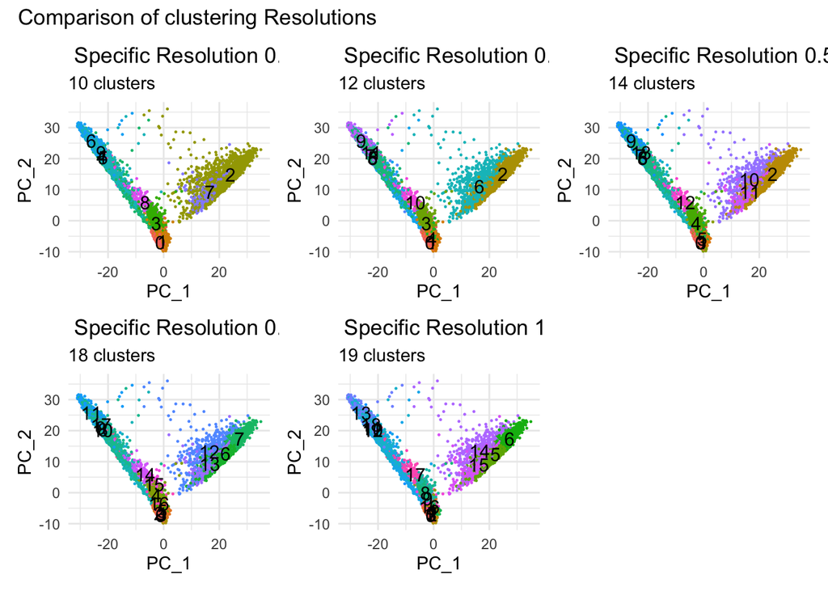

```r
# Visualizing the different clusters
# Create comparison plots for different resolutions
resolution_plots <- list()
resolutions <- c(0.1, 0.3, 0.5, 0.7, 1)

for(i in seq_along(resolutions)) {
  res <- resolutions[i]
  plot_name <- paste0("RNA_snn_res.", res)

  resolution_plots[[i]] <- DimPlot(unified_df_clusters,
                                   group.by = plot_name,
                                   label = TRUE,
                                   label.size = 4) +
    labs(title = paste(" Specific Resolution", res),
         subtitle = paste(length(unique(unified_df_clusters@meta.data[[plot_name]])), "clusters")) +
    theme_minimal() +
    theme(legend.position = "none") }

# Combine all resolution plots
resolution_comparison <- wrap_plots(resolution_plots, ncol = 3)
resolution_comparison <- resolution_comparison +
  plot_annotation(title = "Comparison of clustering Resolutions")

# Save the resolution comparison
ggsave("../results/figures/clustering_resolutions_comparison.png",  plot = resolution_comparison,  width = 15,  height = 10,  dpi = 300, units = "in")

print(resolution_comparison)
```

What we can observe from the different resolutions is that:

- The resolution 0.1 shows well-separated cells populations, and it captures the majority of the cell lineages.
- The resolution 0.3 to 0.5 subdivides the populations into smaller and more specific groups.
- The resolution 0.5 to 1 shows a progressive subdivision of the populations, wich becomes a risk of over-clustering.

## Non-Linear Dimensionality Reduction (UAMP)

After the PCA analysis, our data still exists in high-dimensional space, which is 10 dimensions from the first 10 principal components, which makes impossible to visualize it. This is why we applied the non-linear dimensional reduction technique UMAP (Uniform Manifold Approximation and Projection). This technique will reduce the 10-dimensional PCA space down to 2 dimensions for an optimal visualization, while maintaining the local neighborhood relationships of the cells.

```r
# Non-linear dimensionality reduction
unified_df_clusters_UMAP <-RunUMAP(unified_df_clusters, dims = 1:10)
```

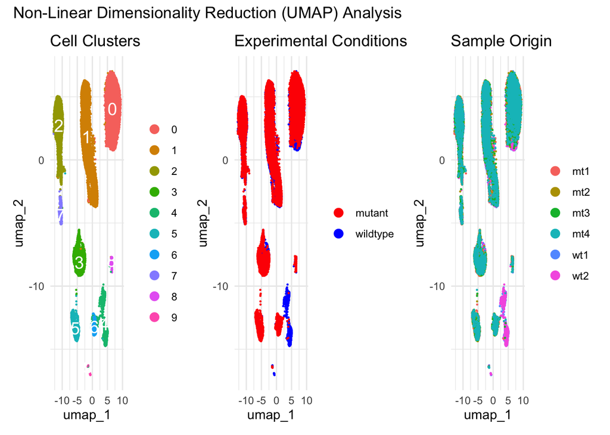

```r
# Visualization of the UMAP clusters and different conditions
clusters_plot <- DimPlot(unified_df_clusters_UMAP, reduction = "umap", group.by = "RNA_snn_res.0.1", label = TRUE,
                         label.size = 5, label.color = "white") + labs(title = "Cell Clusters") + theme_minimal()
conditions_plot <- DimPlot(unified_df_clusters_UMAP, reduction = "umap", group.by = "condition",cols = c("wildtype" = "blue", "mutant" = "red")) +
  labs(title = "Experimental Conditions") +
  theme_minimal()
origin_plot <- DimPlot(unified_df_clusters_UMAP, reduction = "umap", group.by = "orig.ident") + labs(title = "Sample Origin") + theme_minimal()

umap_comparison <- clusters_plot + conditions_plot + origin_plot +
  plot_layout(ncol = 3) +
  plot_annotation(
    title = "Non-Linear Dimensionality Reduction (UMAP) Analysis"
  )

ggsave("../results/figures/UMAP_comparison_three_panel.png",
       plot = umap_comparison,
       width = 18, height = 6, dpi = 300, units = "in")

print(umap_comparison)
```

# Differential Expression Analysis (DEA)

The next step is differential expression analysis (DEA), this is the process of “identifying genes that have a significant difference in expression between two or more groups, we can use different tools for differential gene expression analysis, depending on the underlying statistics” (CCR Bioinformatics Core, National Cancer Institute (2021)). In our case, we’re comparing mutant versus wildtype cells to understand how the genetic mutation affects gene expression patterns.

```r
# We are going to set the identity of the cells based on the condition
Idents(unified_df_clusters_UMAP) <- "condition"

# Join the data layers
unified_df_clusters_UMAP <- JoinLayers(unified_df_clusters_UMAP)

# Use the FindMarkers function to determine the differentially expressed genes
de_genes <- FindMarkers(unified_df_clusters_UMAP, ident.1 = "mutant", ident.2 = "wildtype", test.use = "wilcox", min.pct = 0.1, logfc.threshold = 0.25)
```

[output not shown]

```r
# Check the results
head(de_genes, 10)
```

|  | p_val | avg_log2FC | pct.1 | pct.2 | p_val_adj |
| --- | --- | --- | --- | --- | --- |
| Jon99Cii | 0 | -2.663919 | 0.171 | 0.665 | 0 |
| LysD | 0 | -2.679304 | 0.126 | 0.554 | 0 |
| Cp36 | 0 | -1.945621 | 0.162 | 0.502 | 0 |
| CG12374 | 0 | -2.868906 | 0.070 | 0.407 | 0 |
| Cp19 | 0 | -1.718380 | 0.204 | 0.512 | 0 |
| lncRNA:alphagamma-element:CR32865 | 0 | -2.866508 | 0.227 | 0.518 | 0 |
| Cp15 | 0 | -1.165502 | 0.567 | 0.850 | 0 |
| Hsp26 | 0 | -1.435950 | 0.288 | 0.560 | 0 |
| Hsp70Bc | 0 | -3.147649 | 0.083 | 0.348 | 0 |
| Hr38 | 0 | -1.811713 | 0.146 | 0.384 | 0 |

```r
# Save the results into a csv file
write.csv(de_genes, "../results/tables/DEG_Mutant_vs_WildType.csv", row.names = TRUE)
```

What we can observe in these results is that *the top differentially expressed genes demonstrate a consistent downregulation in mutant cells* with values of log2FC:-1.16 to -3.15), which affects the inmmune response (Jon99Cii, LysD), structural proteins (Cp36, Cp19, Cp15) and stress response (Hsp26, Hsp70Bc). Based on these results, this reduced expression in the mutant cells suggest that the mutation is disrupting the normal gene expression programs.

# Cluster Specific - DEA

The inclusion of a cluster-specific differential expression analysis demonstrates a critical improvement of scRNA-seq in comparison with bulk comparison, as different cell types could respond in an opposite way to the same mutation. An example of this is that, if a mutation upregulate stress genes in one cell type and downregulate the neural genes in another, if we analyze them together, these opposite effects will cancel each other out, masking important specific responses of a cell type.

```r
# Select the identity of the cells based on the cluster
Idents(unified_df_clusters_UMAP) <- "seurat_clusters"

# Create the subset of cells that belongs to cluster 0
cluster_0_cells <- subset(unified_df_clusters_UMAP, idents = "0")

# Select set the identity of the cells based on the condition
Idents(cluster_0_cells) <- "condition"

# Identification of differential expressed genes withing cluster 0
cluster_0_deg <- FindMarkers(cluster_0_cells,ident.1 = "mutant", ident.2 = "wildtype", test.use = "wilcox", min.pct = 0.1, logfc.threshold = 0.25)

# Check the results
head(cluster_0_deg, 10)
```

|  | p_val | avg_log2FC | pct.1 | pct.2 | p_val_adj |
| --- | --- | --- | --- | --- | --- |
| Hsp70Bc | 0.000000e+00 | -5.951074 | 0.016 | 0.488 | 0.000000e+00 |
| stv | 1.039814e-293 | -2.342687 | 0.462 | 0.915 | 1.303615e-289 |
| Jon99Cii | 5.824857e-267 | -2.827099 | 0.163 | 0.670 | 7.302623e-263 |
| lncRNA:alphagamma-element:CR32865 | 9.558326e-260 | -3.201604 | 0.263 | 0.747 | 1.198327e-255 |
| LysD | 1.191616e-215 | -2.731904 | 0.134 | 0.568 | 1.493929e-211 |
| rdgA | 2.295534e-168 | 1.209881 | 0.974 | 0.828 | 2.877911e-164 |
| Jon25Biii | 6.993511e-149 | -4.641627 | 0.009 | 0.189 | 8.767765e-145 |
| DnaJ-1 | 1.664465e-135 | -2.228214 | 0.172 | 0.523 | 2.086740e-131 |
| CG12374 | 2.622298e-131 | -2.666177 | 0.070 | 0.349 | 3.287575e-127 |
| Cp36 | 2.431797e-124 | -1.906930 | 0.169 | 0.514 | 3.048745e-120 |

```r
# Save the results into a csv file
write.csv(cluster_0_deg, "../results/tables/Cluster_0_DEG_Mutant_vs_WildType.csv",row.names = TRUE)

# Overall top 5 DE genes
top5_overall <- head(de_genes[de_genes$p_val_adj < 0.05 & de_genes$avg_log2FC < 0, ], 5)

# Cluster 0 top 5 DE genes
top5_cluster0 <- head(cluster_0_deg[cluster_0_deg$p_val_adj < 0.05 & cluster_0_deg$avg_log2FC < 0, ], 5)

# Create simple comparison table
if(nrow(top5_overall) >= 5 & nrow(top5_cluster0) >= 5) {
  comparison_table <- data.frame(
    Rank = 1:5,
    Overall_Gene = rownames(top5_overall)[1:5],
    Overall_LogFC = round(top5_overall$avg_log2FC[1:5], 2),
    Cluster0_Gene = rownames(top5_cluster0)[1:5],
    Cluster0_LogFC = round(top5_cluster0$avg_log2FC[1:5], 2)
  )

  print(comparison_table)
} else {
  print("Not enough genes for comparison table")
}
```

```
##   Rank Overall_Gene Overall_LogFC                     Cluster0_Gene
## 1    1     Jon99Cii         -2.66                           Hsp70Bc
## 2    2         LysD         -2.68                               stv
## 3    3         Cp36         -1.95                          Jon99Cii
## 4    4      CG12374         -2.87 lncRNA:alphagamma-element:CR32865
## 5    5         Cp19         -1.72                              LysD
##   Cluster0_LogFC
## 1          -5.95
## 2          -2.34
## 3          -2.83
## 4          -3.20
## 5          -2.73
```

This comparison demonstrates why cluster-specific analysis is valuable in scRNA-seq. While both analyses show overlapping genes like Jon99Cii and LysD, cluster 0 reveals that there are unique patterns, specifically the the -5.95 fold downregulation of Hsp70Bc. This severe reduction suggests that the cells that belongs to cluster 0 have a diferent response to the mutation,which is a possible indicator of an altered protein.

# Data Visualization

## Volcano Plots

The volcano plots will be used to visualize the differential expression results.

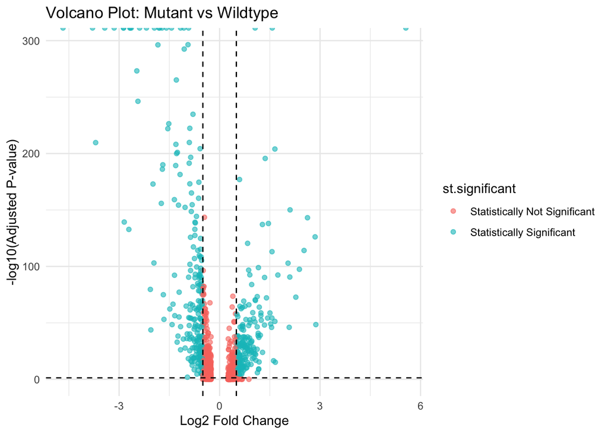

```r
# Include the gene names and significance labels for plotting
de_genes$gene <- rownames(de_genes)
de_genes$st.significant <- ifelse(de_genes$p_val_adj < 0.05 & abs(de_genes$avg_log2FC) > 0.5, "Statistically Significant", "Statistically Not Significant")

# Create Volcano Plot for Visualization
volcano_plot <- ggplot(de_genes, aes(x = avg_log2FC, y = -log10(p_val_adj), color = st.significant)) + geom_point(alpha = 0.6) + theme_minimal() +
  labs( title = "Volcano Plot: Mutant vs Wildtype",
        x = "Log2 Fold Change",
        y = "-log10(Adjusted P-value)") +
        geom_hline(yintercept = -log10(0.05), linetype = "dashed") +
        geom_vline(xintercept = c(-0.5,0.5), linetype = "dashed")

ggsave("../results/figures/volcano_plot.png",
       plot = volcano_plot,
       width = 10, height = 8, dpi = 300, units = "in")

print(volcano_plot)
```

This volcano plots is demonstrating te differential expression between mutant and wildtype cells, where in th e horizontal dashed line we can observe the significante threshold (p < 0.05) and the vertical line demonstrating the +- 0.5 log2FC cutoffs. The distribution is demonstrating that there is a clear downregulation, as more genes presents negative fold changes (left) than positive ones. This confirms that the mutation is primarly supressing the gene expression rather than activating new pathways.

## Feature Plot

The FeaturePlot is going to maps the specific gene expression level to the UMAP coordinates, which will create individual plots for each gene of interest. The dots in the graph represents a single cells positioned following the UMAP coordinates and the color is an indicator of the expression level of the gene in that cell. This visualization will help us to determine:

- Which cells types normally express each gene.
- Which cell types demonstrate the strongest downregulation effects.
- If the expression changes are uniform across all the cell population or if they are restricted to a specific cluster.

```r
# Select the top upregulated and downregulates genes to plot
top_upregulated_genes <- head(de_genes[de_genes$avg_log2FC > 0 & de_genes$p_val_adj < 0.05, ], 5)
top_downregulated_genes <- head(de_genes[de_genes$avg_log2FC < 0 & de_genes$p_val_adj < 0.05, ], 5)

# Determine the actual fold changes to better understand expresion
print("Upregulated genes:")
```

```
## [1] "Upregulated genes:"
```

```r
print(top_upregulated_genes[,c("avg_log2FC", "p_val_adj")])
```

```
##         avg_log2FC     p_val_adj
## CG4291    5.561377  0.000000e+00
## CG5830    1.572957  0.000000e+00
## CG10077   1.060843  0.000000e+00
## CG5399    1.651173 1.009756e-204
## betaTry   1.361534 2.252315e-196
```

```r
print("Downregulated genes:")
```

```
## [1] "Downregulated genes:"
```

```r
print(top_downregulated_genes[,c("avg_log2FC", "p_val_adj")])
```

```
##          avg_log2FC p_val_adj
## Jon99Cii  -2.663919         0
## LysD      -2.679304         0
## Cp36      -1.945621         0
## CG12374   -2.868906         0
## Cp19      -1.718380         0
```

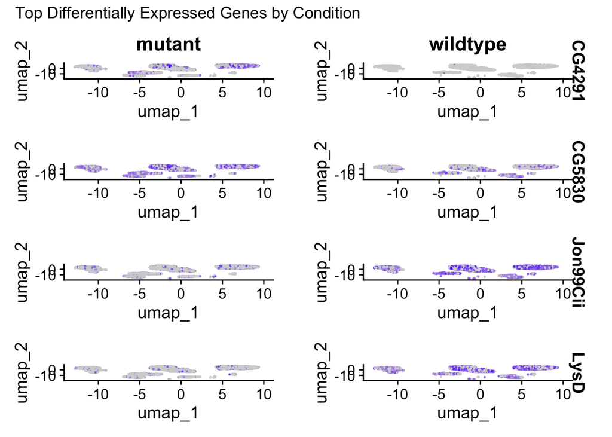

```r
# Feature plots showing expression of top genes split by condition
if(nrow(top_upregulated_genes) > 0 & nrow(top_downregulated_genes) > 0) {
  feature_plots <- FeaturePlot(unified_df_clusters_UMAP, features = c(rownames(top_upregulated_genes)[1:2], rownames(top_downregulated_genes)[1:2]),
              split.by = "condition", ncol = 2) + plot_annotation(title = "Top Differentially Expressed Genes by Condition")

  ggsave("../results/figures/feature_plots_top_genes.png",
         plot = feature_plots,
         width = 12, height = 10, dpi = 300, units = "in")

  print(feature_plots)
}
```

## Violin Plot

The Violin plot is going to show the distribution of gene expression levels across different groups with three key features:

- The width represents the density, how many cells have that expression level.
- The height represents the range of expression values, the taller the broader expression range.
- The shape is the distribution pattern, the smooth curve shows expression patterns.

```r
# Violin plots showing cluster-specific expression patterns
violin_deg_plot <-VlnPlot(unified_df_clusters_UMAP,
        features = c("CG4291", "Jon99Cii"),
        split.by = "condition",
        group.by = "seurat_clusters",
        pt.size = 0) +
  plot_annotation(title = "Expression Patterns of Key DE Genes by Cluster and Condition") +
  theme(legend.position = "bottom",
        legend.title = element_text(size = 12),legend.text = element_text(size = 10))
```

```
## The default behaviour of split.by has changed.
## Separate violin plots are now plotted side-by-side.
## To restore the old behaviour of a single split violin,
## set split.plot = TRUE.
##
## This message will be shown once per session.
```

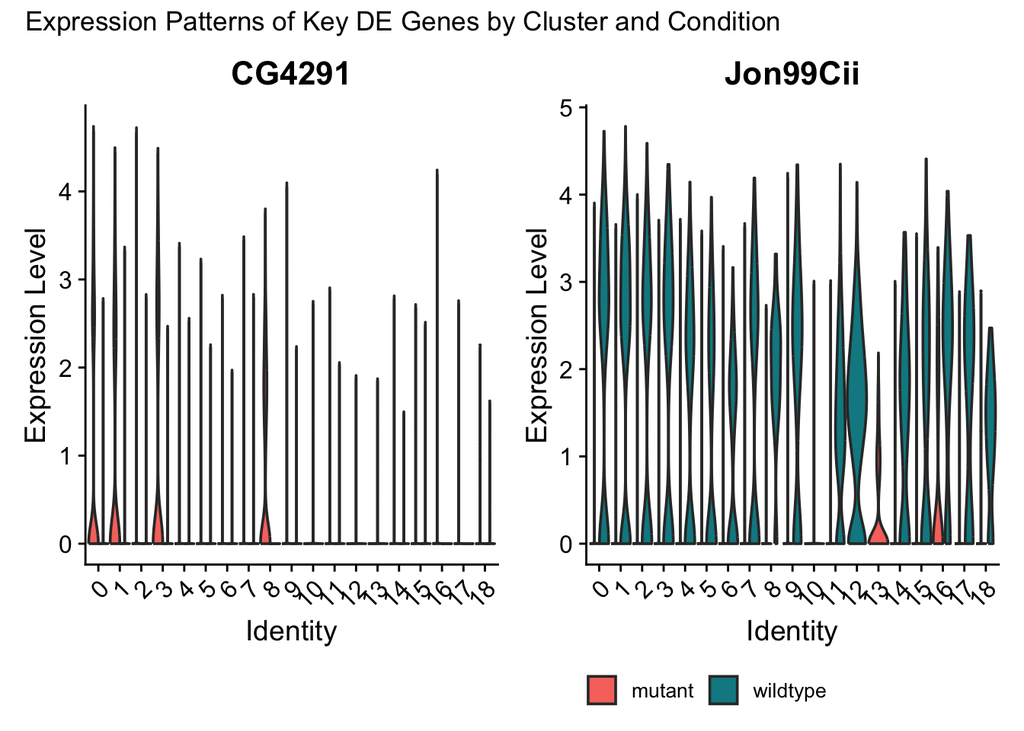

```r
ggsave("../results/figures/violin_plots_key_genes.png",
       plot = violin_deg_plot,
       width = 12, height = 8, dpi = 300, units = "in")

print(violin_deg_plot)
```

These plots demonstrate cluster-specific expression patterns for both genes.

# Data Summary

```r
# Store the sesion info for future reproductibility
writeLines(capture.output(sessionInfo()), "../environment/sessionInfo.txt")

# Include a summary of the datasets
print(paste("Final dataset has: ", ncol(unified_df_clusters_UMAP), " cells, and ", nrow(unified_df_clusters_UMAP), " genes."))
```

```
## [1] "Final dataset has:  25014  cells, and  12537  genes."
```

```r
print(paste("The number of clusters identified is:", length(unique(unified_df_clusters_UMAP$seurat_clusters))))
```

```
## [1] "The number of clusters identified is: 19"
```

```r
print(paste("The number of significant differentially expressed genes (overall) is:", sum(de_genes$p_val_adj < 0.05)))
```

```
## [1] "The number of significant differentially expressed genes (overall) is: 866"
```

```r
print(paste("The number of Significant differentially expressed genes (cluster 0):", sum(cluster_0_deg$p_val_adj < 0.05)))
```

```
## [1] "The number of Significant differentially expressed genes (cluster 0): 384"
```

```r
cat("Top 5 upregulated genes:", paste(head(rownames(top_upregulated_genes), 5), collapse = ", "), "\n")
```

```
## Top 5 upregulated genes: CG4291, CG5830, CG10077, CG5399, betaTry
```

```r
cat("Top 5 downregulated genes:", paste(head(rownames(top_downregulated_genes), 5), collapse = ", "), "\n")
```

```
## Top 5 downregulated genes: Jon99Cii, LysD, Cp36, CG12374, Cp19
```

```r
# Clusters cells composition and comparison between mutant and wildtype
cluster_composition_table <- unified_df_clusters_UMAP@meta.data %>%
  group_by(seurat_clusters, condition) %>%
  summarise(n_cells = n(), .groups = "drop") %>%
  pivot_wider(names_from = condition, values_from = n_cells, values_fill = 0) %>%
  mutate(total_cells = wildtype + mutant,
         pct_wildtype = round(wildtype/total_cells * 100, 1),
         pct_mutant = round(mutant/total_cells * 100, 1))

write.csv(cluster_composition_table, "../results/tables/cluster_composition_by_condition.csv", row.names = FALSE)

# After all processing steps in Seurat
saveRDS(unified_df_clusters_UMAP, file = "../results/final_seurat.rds")
```

# Conclusions

Based on the results that we have obtained from the sequencing analysis, some of the conclusions that we could draw from them are:

Regarding the *biological implications* of this analysis, what we can observe is that this mutation can compromise the stress response mechanisms of the cells. Nevertheless, as the cell type diversity is mantained even through the mutated cells, this suggest that this mutation is not affecting the early developmental programs of the organism.

This single-cell RNA sequencing analysis has reveal us that the mutation that we have studied is causing a downregulation of the genes that are involved in the immune response, and also in the stress response and the strucutural maintenance. In addition to this, the cell-type specific analysis is demonstrate that the different population of cells are afected differently by the mutation, as some clusters have a severe disruption of the protein, such as the Hsp70BC protein. These findings offer important insights about the molecular mechanisms of the mutant phenotype.

CCR Bioinformatics Core, National Cancer Institute. 2021. “Getting Started with Seurat: Differential Expression and Classification.” 2021. https://bioinformatics.ccr.cancer.gov/docs/getting-started-with-scrna-seq/Seurat_DifferentialExpression_Classification/.

Yamada, Shintaro, and Seitaro Nomura. 2020. “Review of Single-Cell RNA Sequencing in the Heart.” *International Journal of Molecular Sciences* 21 (21): 8345. https://doi.org/10.3390/ijms21218345.